# Ford GoBike System Data Analysis

## by Francis Wesa Wobulu

## Investigation Overview

In this investigation, I looked at how the duration of trips changes with respect to DateTime and user type. I also looked at the distibution of the bike rides and their gender. The main focus was on hours of the day, days of the week and customer type

## Dataset Overview

The dataset consists of information regarding approximately 183,412 rides made in a bike-sharing system covering the greater San Francisco Bay area. The data features include duration (secs) and others such as DateTime, user_type, and member_gender, as well as additional variables such as member's year of birth, start and end station name, start and end station longitude and latitude among others.

## Distribution of Bike Rides among User Type

- Subscribers account for the hihest number of Bike rides taken.

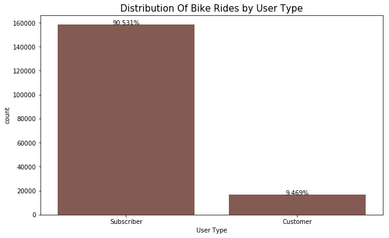

### Distribution of Bike trips based on the Day of the week

- Most trips were taken between Monday and Friday with Thursday having the highest number of trips taken.
- Sunday and Sartuday recorded a low number of trips

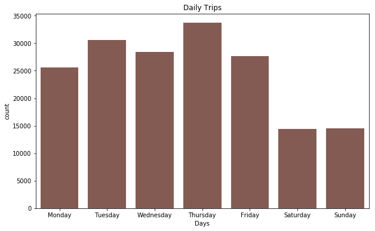

## Distribution of Bike trips based on the Time of Day

- The ditribution above shown by the frequency of bike trips during the day is bimodal.
- There is peak bike rides between 8 and 9 in the morning and between 5 and 6 in the evening

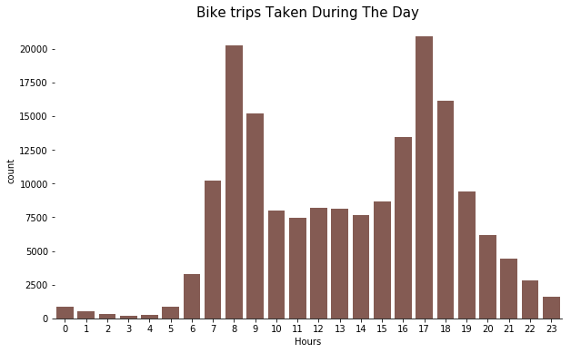

## Bike Ride distribution based on gender

- Most of the Bike Trips were taken by Males

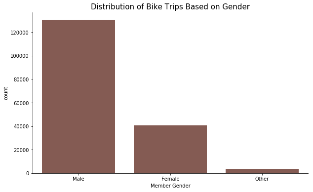

### Comparison of rides taken by member_gender at various times of the day

- Females took the least number of rides during early mornings and late at night.
- Males generally are the largest group of bike riders throughout the day

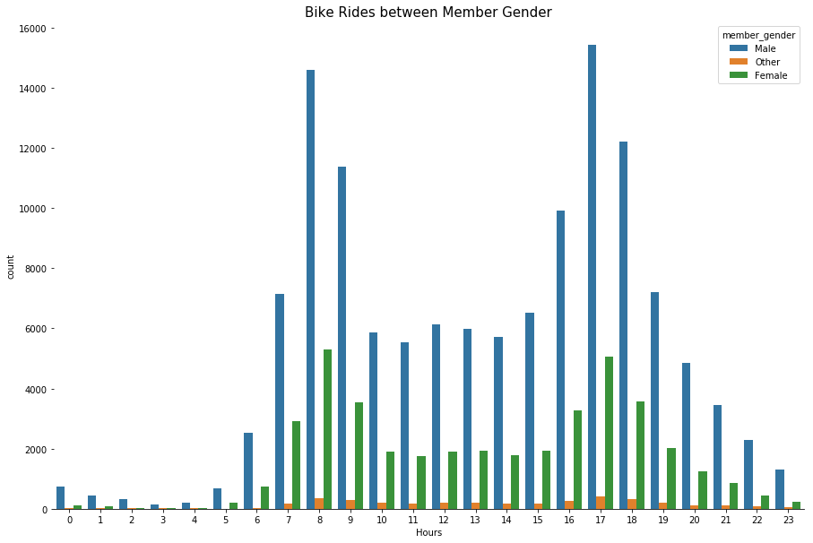

## comparison of bike usage among user type during the day

- A lot of bike rides were taken by subscibers compared to customers

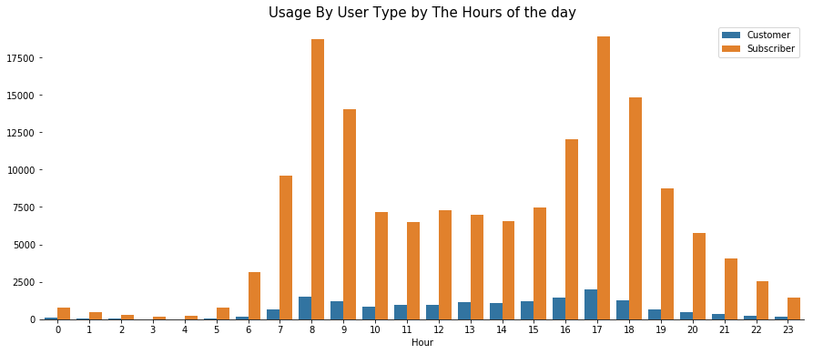